# Tutorial for mNSF package

### Yi Wang and Kasper Hansen

### May, 2024

## Abstract

mNSF is a package for spatial factorization for multi-sample spatial transcriptomics data

Spatial resolved transcriptomics opens the door to analyzing gene expression data in the context of spatial position. Recently, Townes and Engelhardt developed NSF, a non-negative spatial matrix factorization method. NSF can be used to identify spatial-dependent latent factors that are associated with functional anatomical regions. However, the model formulation is currently limited to a single sample.

However, an increasing number of spatial datasets contain multiple samples from different tissue sections. Properly modeled, such datasets could potentially allow us to identify matched regions across samples and increase the confidence in downstream analysis. However, there are few existing analysis methods for spatial data which allow joint analysis of multiple samples.

Here, we extend NSF to allow for multi-sample analysis. Our method, which we term mNSF, identifies factors which are common across multiple samples, and does not depend on cross-sample spot alignment, which is currently a challenging problem. In simulations, our method is capable of identifying spatial structures which are rotated between samples, as well as structures which only appear in some, but not all, samples. Using real data, we show our method is capable of identifying matched functional regions in multi-sample spatial transcriptomics data.

## 1. Introduction

The mNSF pacakge provides functionality to perform spatial factorization for multi-sample spatial data from spatial transcriptomics, or other multi-sample feature-by-observation high-dimensional matrix, where each observation has provided with the spatial location mNSF expects as input data: *feature-by-observation matrix, where each row is one feature(gene) and each column is one obsercation(spot) *the matrix for the coordinated of each observation correspondingly

mNSF expects as input parameter: *number of factors *number of samples

mNSF generate the output: *a factor matrix, where each column is one factor, for each sample *a loading matrix, where each row is correpsonding to one gene, and each column correpsonds to one factor

### 1.1 Citing mNSF

If you use this package, please cite (Wang et al. 2024).

### 1.2 Dependencies

This document has the following dependencies

```python
import random
import os
import numpy as np
import tensorflow as tf
import pandas as pd
import sys
import pickle
from scanpy import pp
from os import path
```

[output not shown]

## 2. Install mNSF

For installation of mNSF, follow the guidance on: https://github.com/hansenlab/mNSF

## 3. Import mNSF package after intallation

```python
dir_mNSF_functions='/users/ywang/Hansen_projects/scRNA/mNSF_2023_10_20/'
dir_output="/dcs04/hansen/data/ywang/ST/DLPFC/PASTE_out_keepAll_scTransform/"

import mNSF
sys.path.append(dir_mNSF_functions)
from mNSF import process_multiSample
from mNSF.NSF import preprocess
from mNSF.NSF import misc
from mNSF import training_multiSample
from mNSF import process_multiSample
from mNSF.NSF import visualize
from mNSF.NSF import misc


sys.path.append(dir_output)
os.chdir(dir_output)
```

```
Invoking __inity__.py in mNSF
```

## 4. Set up the parameters of mNSF

### 4.1 Set L, the number of factors

```python
L=2
```

#### Set nsample, the number of samples in the data

```python
nsample=2
```

### Set up paths for storing the outputs of mNSF

Set the path for storing the trained model

```python
mpth = path.join("models")
misc.mkdir_p(mpth)
```

Set the path for storing the plots

```python
pp = path.join(mpth,"pp",str(2))
misc.mkdir_p(pp)
```

## 5. Getting your data into mNSF

### 5.1 Load the data and store the data into a list format

Input objects: Y: gene count matrix for each sample X: coordinate matrix for each sample

Output objects: list_D: a list where each item contains information for one sample list_X: a list where each item is the coordinate matrix for one sample

mNSF functions used: process_multiSample.get_D:process the raw data of each sample, and create a object that contains the full information for one sample

```python
list_D=list()
list_X=list()

for ksample in range(0,nsample):
	Y=pd.read_csv(path.join('//dcs04/hansen/data/ywang/ST/DLPFC/processed_Data//Y_features_sele_sample'+str(ksample+1)+'_500genes.csv'))
	X=pd.read_csv(path.join('//dcs04/hansen/data/ywang/ST/DLPFC/processed_Data///X_allSpots_sample'+str(ksample+1)+'.csv'))
	D=process_multiSample.get_D(X,Y)
	list_D.append(D)
	list_X.append(D["X"])
```

### 5.2 Process the data into the format as the input of mNSF

Output objects: list_Dtrain: a list where each item is the training data for one sample (here mNSF uses all the data as training data by default) list_sampleID: a list where each item is the sample ID for one sample Z: matrix for the cooordinates of induced points

mNSF functions used: process_multiSample.get_listDtrain: exract the training data stored in list_D process_multiSample.get_listSampleID: exract the sample ID information for each sample stored in list_D

Parameters ninduced: number of induced points used

```python
list_Dtrain=process_multiSample.get_listDtrain(list_D)
list_sampleID=process_multiSample.get_listSampleID(list_D)


# set induced points, 15% of total spots for each sample
for ksample in range(0,nsample):
	random.seed(111)
	ninduced=round(list_D[ksample]['X'].shape[0] * 0.15)
	random.seed(222)
	print(ninduced)
	D=list_D[ksample]
	rd_ = random.sample(range(0, D['X'].shape[0]), ninduced)
	list_D[ksample]["Z"]=D['X'][rd_ ,:]
```

```
634
658
```

## 6. Run mNSF model initialization

mNSF initialize the parameter and the factors by applying NMF on the concatenated gene expression matrix

```python
list_fit=process_multiSample.ini_multiSample(list_D,L,"nb")
```

```
fit_set_loadings
1
2
2
0
1
(4,)
```

## 7. Run mNSF model training

Model training, using 2 epochs. mNSF set 500 epochs as maximal number of epochs by default.

Parameters epochs: maximal number of epochs used in the training

Output list_fit: a list where each item contains the parameters and factors estimated by mNSF Plot of loss: The plot will be created for showing the loss of each iteration of mNSF model training

```
Temporary checkpoint directory: /tmp/tmp8uvt6_u3
0002 train: 1.992e+03
0002 training complete, reached maximum epochs.
```

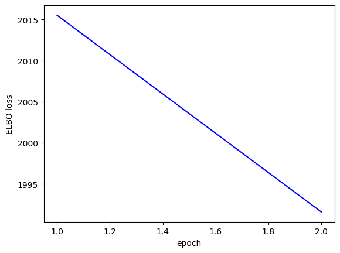

```python
list_fit=training_multiSample.train_model_mNSF(list_fit,pp,list_Dtrain,list_D,num_epochs=2)
```

## 7. Plot the mNSF factors in the space

Plot these two mNSF factors in sample 1

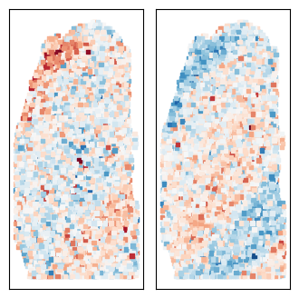

```python
Fplot = misc.t2np(list_fit[0].sample_latent_GP_funcs(list_D[0]["X"], S=3, chol=False)).T
hmkw = {"figsize":(4,4),"bgcol":"white","subplot_space":0.1,"marker":"s","s":10}
fig,axes=visualize.multiheatmap(list_D[0]["X"], Fplot, (1,2), cmap="RdBu", **hmkw)
```

Plot the two mNSF factors in sample 2

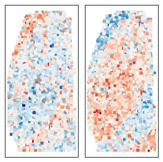

```python
Fplot = misc.t2np(list_fit[1].sample_latent_GP_funcs(list_D[1]["X"], S=3, chol=False)).T
hmkw = {"figsize":(4,4),"bgcol":"white","subplot_space":0.1,"marker":"s","s":10}
fig,axes=visualize.multiheatmap(list_D[1]["X"], Fplot, (1,2), cmap="RdBu", **hmkw)
```